# Lab 4 - Hidden Markov Models

Nick Chambers, Madison Shipley, Karl Veggerby

May 9, 2023

# Data set

In this lab, we’re looking at ecological indicators and exploring hidden Markov models and probabilities of shifting between underlying states.

## Load the data

We explored the `stoplight.csv` dataset for this week. One of the columns divides indicators into groups (e.g. Climate, Local Physical, Local Biological, etc) and we wanted to look at some biological indicators and climate/physical indicators.

```r
stoplight <- read.csv(here::here("Lab-4", "stoplight.csv"))
head(stoplight)
```

```
##   Ecosystem.Indicators           Type X1998 X1999 X2000 X2001 X2002 X2003 X2004
## 1         PDO_DecMarch        Climate  5.07 -1.75 -4.17  1.86 -1.73  7.45  1.85
## 2         PDO_MaySept)        Climate -0.37 -5.13 -3.58 -4.22 -0.26  3.42  2.96
## 3                  ONI        Climate  1.12 -1.07 -1.07 -0.40  0.18  0.27  0.20
## 4                  SST Local Physical 13.77 13.20 13.33 12.98 13.05 13.56 14.68
## 5     Upper_20m_NovMar Local Physical 12.30 10.31 10.12 10.22 10.08 10.70 10.86
## 6    Upper_20m_MaySept Local Physical 10.35 10.07 10.16  9.76  8.99  9.62 11.31
##   X2005 X2006 X2007 X2008 X2009 X2010 X2011 X2012 X2013 X2014 X2015 X2016 X2017
## 1  2.44  1.94 -0.17 -3.06 -5.41  2.17 -3.65 -5.07 -1.67  1.24  9.26  6.69  3.38
## 2  3.48  0.28  0.91 -7.63 -1.11 -3.53 -6.45 -7.79 -3.47  5.07  8.08  6.60  2.18
## 3  0.47 -0.30  0.08 -0.98 -0.23  0.55 -0.72 -0.43 -0.30 -0.28  0.67  1.22  0.13
## 4 13.58 12.73 13.64 12.45 13.44 12.76 13.23 13.34 13.72 14.03 13.89 13.83 13.59
## 5 10.61 10.59 10.04  9.33 10.19 11.01 10.02  9.62 10.12  9.62 12.73 12.03 11.47
## 6 10.73  9.97 10.07  9.30  9.90 10.42  9.95  9.92 10.43 10.95 10.69 10.32 10.14
##   X2018 X2019 X2020 X2021
## 1  1.52  2.01 -0.76 -2.77
## 2  0.45  3.94 -1.35 -6.64
## 3 -0.45  0.72  0.28 -0.72
## 4 13.71 14.68 13.40 12.95
## 5 10.63 10.99  9.37 10.12
## 6 10.34 11.31 10.87  9.85
```

## Wrangle the data

We initially selected the Pacific Decadal Osculation (PDO) for the Dec/March period, sea surface temperature (SST), and copepod richness and ichthy communitiy index, which we assumed was comperable to copepod richness (though maybe not).

```r
#ecosystem indicators
stoplight[,1]
```

```
##  [1] "PDO_DecMarch"
##  [2] "PDO_MaySept)"
##  [3] "ONI"
##  [4] "SST"
##  [5] "Upper_20m_NovMar"
##  [6] "Upper_20m_MaySept"
##  [7] "Deep_temperature"
##  [8] "Deep_salinity"
##  [9] "Copepod_richness"
## [10] "N_copepod"
## [11] "S_copepod"
## [12] "Biological_transition"
## [13] "Nearshore_Ichthyoplankton"
## [14] "Ichthy_community_index"
## [15] "Chinook_salmon_juv"
## [16] "Coho_salmon_juv"
## [17] "Principal Component scores (PC1)"
## [18] "Principal Component scores (PC2)"
## [19] "Physical Spring Trans.\nUI based (day of year)"
## [20] "Physical Spring Trans. Hydrographic (day of year)"
## [21] "Upwelling Anomaly\n(Sum April-May)"
## [22] "Length of Upwelling Season\nUI based (days)"
## [23] "Copepod Community Index\n(MDS axis 1 scores; May-Sept)"
```

```r
years<-seq(1998,2021,1)

#ecosystem indicators to pull
PDO_DecMarch<-unlist(as.vector(stoplight[1,3:26]))
SST<-unlist(as.vector(stoplight[4,3:26]))
Copepod_richness<-unlist(as.vector(stoplight[9,3:26]))
Ichthy_community_index<-unlist(as.vector(stoplight[14,3:26]))

dat<-matrix(nrow=length(years), ncol=5)
dat[,1]<-years
dat[,2]<-PDO_DecMarch
dat[,3]<-SST
dat[,4]<-Copepod_richness
dat[,5]<-Ichthy_community_index
colnames(dat)<-c("years","PDO", "SST", "CopeRich", "FishInx")
rownames(dat)<-seq(1,24,1)

dat<-as.data.frame(dat)
head(dat)
```

```
##   years   PDO   SST CopeRich FishInx
## 1  1998  5.07 13.77     4.54   -9.47
## 2  1999 -1.75 13.20    -2.58  -20.44
## 3  2000 -4.17 13.33    -3.41  -28.90
## 4  2001  1.86 12.98    -1.03  -14.48
## 5  2002 -1.73 13.05    -1.12  -13.98
## 6  2003  7.45 13.56     1.99   -2.29
```

## Data Visualization

The first rule of science is to plot your data! We started with looking at all our data together.

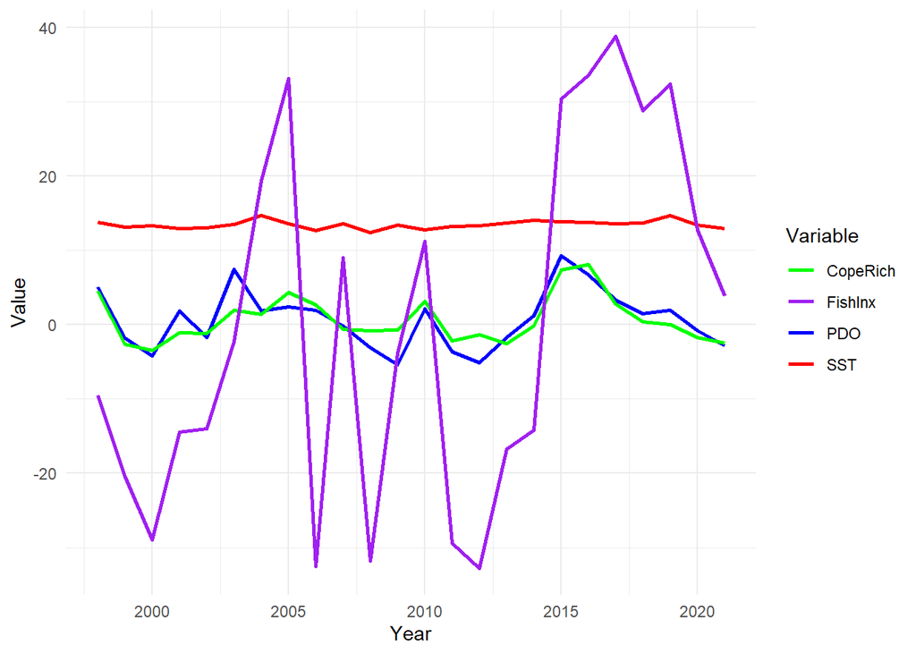

```r
# Plotting all
ggplot(dat, aes(x = years)) +
  geom_line(aes(y = PDO, color = "PDO"), linewidth = 1) +
  geom_line(aes(y = SST, color = "SST"), linewidth = 1) +
  geom_line(aes(y = CopeRich, color = "CopeRich"), linewidth = 1) +
  geom_line(aes(y = FishInx, color = "FishInx"), linewidth = 1) +
  scale_color_manual(values = c(PDO = "blue", SST = "red", CopeRich = "green", FishInx = "purple")) +
  labs(x = "Year", y = "Value", color = "Variable") +
  theme_minimal()
```

Sea surface temperature stats pretty consistent, while the fish index had a significant range, possibly following PDO if you squint, but was not immediatly compelling. We narrowed it down and decided to focus on copepod richness and PDO, which seemed to be incredibly correlated, and plotted the time series and their relationship to each other. In a positive PDO index, there is a positive correlation with copepod index.

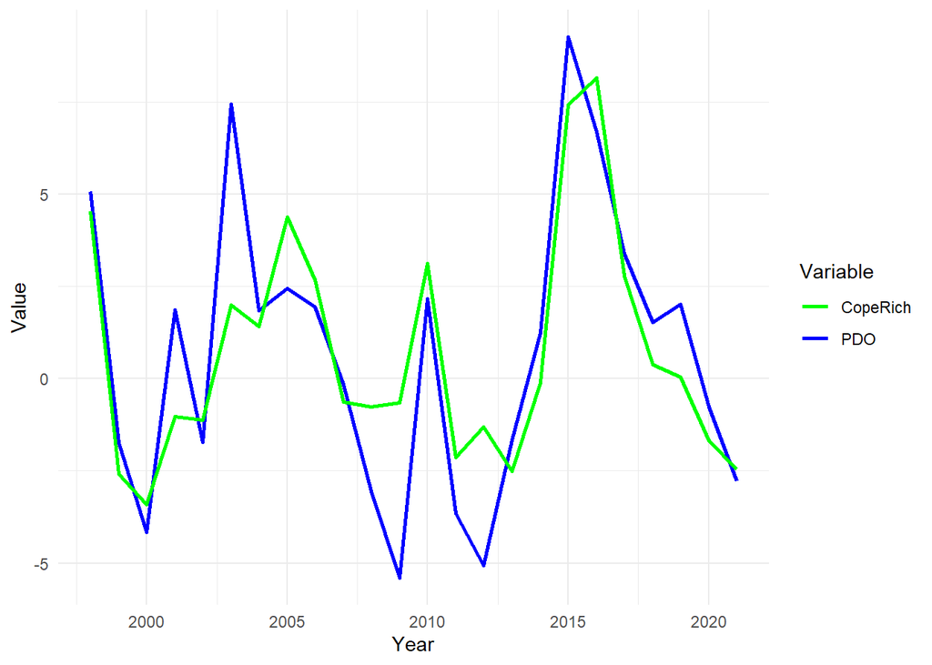

```r
# Plotting Coperich and env cov
ggplot(dat, aes(x = years)) +
  geom_line(aes(y = PDO, color = "PDO"), size = 1) +
  geom_line(aes(y = CopeRich, color = "CopeRich"), size = 1) +
  scale_color_manual(values = c(PDO = "blue", SST = "red", CopeRich = "green", FishInx = "purple")) +
  labs(x = "Year", y = "Value", color = "Variable") +
  theme_minimal()
```

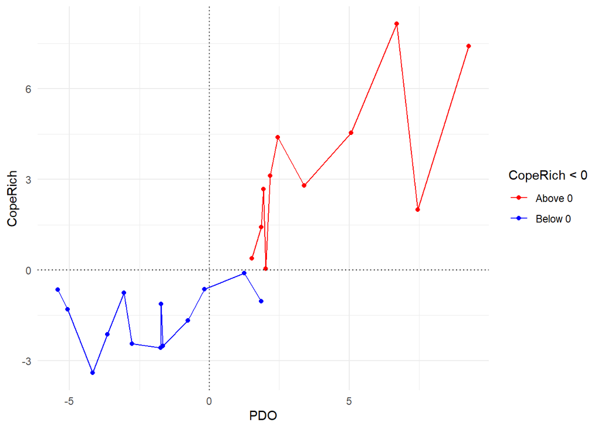

```r
#CopeRichness tracks very closely with PDO
#SST seems to have a negligible correlation

ggplot(dat, aes(x = PDO, y = CopeRich, color = CopeRich < 0)) +
  geom_point() +
  geom_line(aes(x = PDO, y = CopeRich)) +
  geom_hline(yintercept = 0, linetype = "dotted") +
  geom_vline(xintercept = 0, linetype = "dotted") +
  scale_color_manual(values = c("red", "blue"), labels = c("Above 0", "Below 0")) +
  labs(x = "PDO", y = "CopeRich") +
  theme_minimal()
```

```r
#fish index is all over the place, let's not use it.
```

We also wanted to think about our possible hidden states, and while there seems to be a clear two-state sytem with PDO in a negative or positive index, we wondered if there was a third state “weak” index.

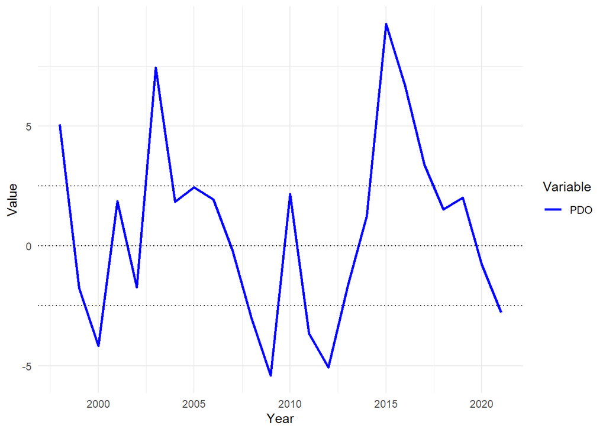

```r
# PDO states
ggplot(dat, aes(x = years)) +
  geom_line(aes(y = PDO, color = "PDO"), size = 1) +
  scale_color_manual(values = c(PDO = "blue", SST = "red", CopeRich = "green", FishInx = "purple")) +
  labs(x = "Year", y = "Value", color = "Variable") +
  geom_hline(yintercept = 0, linetype = "dotted") +
  geom_hline(yintercept = 2.5, linetype = "dotted") +
  geom_hline(yintercept = -2.5, linetype = "dotted") +
  theme_minimal()
```

### Objective tips

Our primary objectives for this lab were to gain a better understanding of hmm options and getting some practice with interpretation by exploring different model options considering copepod richness and PDO. While there was much more we could have done, we decided to explore model specification, and interpretation of AIC for these types of models, which can be misleading depending on the ecological assumptions being made.

# General tasks

- Please pick a type of indicators, and develop a 2- or 3-state multivariate HMM.

# Methods

We fit models with different either two or three states to determine whether copepod richness and/or PDO seems to have 2 or 3 states. It’s unclear if there is a ‘neutral’ state that modulates copepod richness in addition to the hot and cool phases.

We also explored the transition option, by assuming either that there is no covariate informing the transition, or that PDO informed the transition.

We assumed the familys were gaussian for all models tested.

We plotted the fit of all models to copepod richness and PDO data from the stoplight dataset. We then also compared model fits with AIC in an attempt to select the best model.

Note that in the report we give probabilities of transitioning to and from states, but these models are very sensitive to starting conditions, so we iterate over many set seeds for each model to find the best fit. That being said, some of the values written in this report may be different upon knitting.

## Model 1 Copepods only: 2 states

We started with a very simple model, with copepod richness as the intercept and no covariates informing the transition. We started by assuming a two state system.

```r
# Model 1
mod1 = depmix(CopeRich ~1,
                   nstates = 2,
                   transition = ~1,
                   family = gaussian(),
                   data=dat)

fitmod1 = fit(mod1)
```

```
## converged at iteration 11 with logLik: -54.68034
```

```r
#Find best fit
iter <-100
seeds<-sample(100:1000, size = iter, replace = F)
best1 <- 1e10
best_model1 <- NA
for(i in 1:iter){
  set.seed(seeds[i])
  fitmod1 <- fit(mod1)
  if(AIC(fitmod1)< best1){
    best_model1 <- fitmod1
    best1 <- AIC(fitmod1)
  }
}
```

[output not shown]

[output cut: 45 more lines]

[output not shown]

```r
summary(best_model1)
```

```
## Initial state probabilities model
## pr1 pr2
##   1   0
##
## Transition matrix
##         toS1  toS2
## fromS1 0.598 0.402
## fromS2 0.246 0.754
##
## Response parameters
## Resp 1 : gaussian
##     Re1.(Intercept) Re1.sd
## St1           3.504  2.552
## St2          -1.414  1.050
```

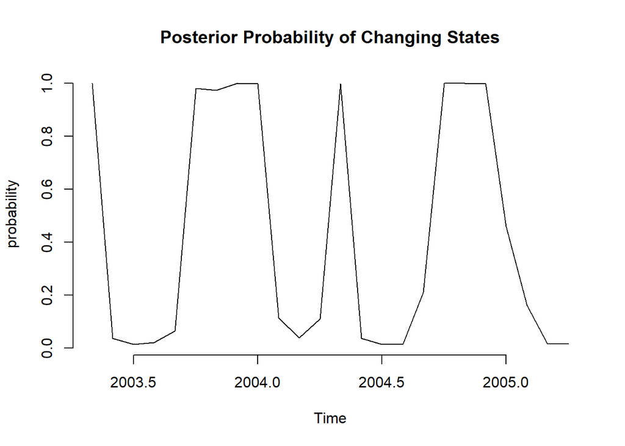

```r
plot(ts(posterior(best_model1, type="smoothing")[,1], start=c(2003,5), deltat=1/12),ylab="probability",
     main="Posterior Probability of Changing States",
     frame=FALSE)
```

```r
prstates <- apply(posterior(best_model1)[,c("S1", "S2")],1, which.max)
mu <- summary(best_model1)[,1]
```

```
## Initial state probabilities model
## pr1 pr2
##   1   0
##
## Transition matrix
##         toS1  toS2
## fromS1 0.598 0.402
## fromS2 0.246 0.754
##
## Response parameters
## Resp 1 : gaussian
##     Re1.(Intercept) Re1.sd
## St1           3.504  2.552
## St2          -1.414  1.050
```

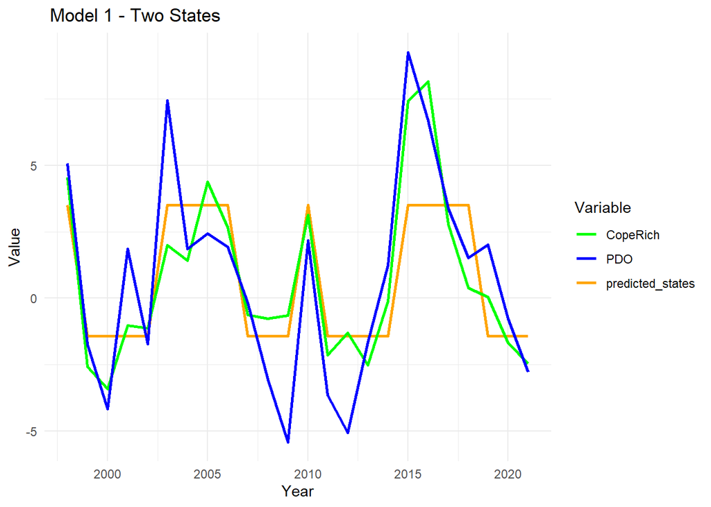

```r
pred <- tibble("Year" = dat$years, "Copepod Richness" = mu[prstates])

#predicted values
pred1<-pred %>%
  pivot_longer(-Year, names_to = "Copepod Richness", values_to = "Fit")

ggplot() +
  geom_line(data = pred1, aes(x = years, y = Fit, color = "predicted_states"), size = 1) +
  geom_line(data = dat, aes(x = years, y = CopeRich, color = "CopeRich"), size = 1) +
  geom_line(data = dat, aes(x = years, y = PDO_DecMarch, color = "PDO" ), size = 1)+
  scale_color_manual(values = c(PDO = "blue", SST = "red", CopeRich = "green",
                                FishInx = "purple", predicted_states = "orange")) +
  labs(title = " Model 1 - Two States", x = "Year", y = "Value", color = "Variable") +
  theme_minimal()
```

Model 1 produces a reasonably good fit to the data.

## Model 2 Copepods only: 3 states

We continued by using the same simple model from above, and assuming 3 states.

```r
# Model 2
mod2 = depmix(CopeRich ~1,
                   nstates = 3,
                   transition = ~1,
                   family = gaussian(),
                   data=dat)

fitmod2 = fit(mod2)
```

```
## converged at iteration 70 with logLik: -53.46158
```

```r
#Find best fit
iter <-100
seeds<-sample(100:1000, size = iter, replace = F)
best2 <- 1e10
best_model2 <- NA
for(i in 1:iter){
  set.seed(seeds[i])
  fitmod2 <- fit(mod2)
  if(AIC(fitmod2)< best2){
    best_model2 <- fitmod2
    best2 <- AIC(fitmod2)
  }
}
```

[output not shown]

[output cut: 45 more lines]

[output not shown]

```r
summary(best_model2)
```

```
## Initial state probabilities model
## pr1 pr2 pr3
##   0   0   1
##
## Transition matrix
##         toS1  toS2  toS3
## fromS1 0.500 0.000 0.500
## fromS2 0.072 0.781 0.147
## fromS3 0.000 0.573 0.427
##
## Response parameters
## Resp 1 : gaussian
##     Re1.(Intercept) Re1.sd
## St1           7.785  0.365
## St2          -1.329  1.079
## St3           2.947  1.124
```

```r
# plot(ts(posterior(best_model1, type="smoothing")[,1], start=c(2003,5), deltat=1/12),ylab="probability",
#      main="Posterior probability of state 1 (copepods good?).",
#      frame=FALSE)

prstates <- apply(posterior(best_model2)[,c("S1", "S2")],1, which.max)
mu <- summary(best_model2)[,1]
```

```
## Initial state probabilities model
## pr1 pr2 pr3
##   0   0   1
##
## Transition matrix
##         toS1  toS2  toS3
## fromS1 0.500 0.000 0.500
## fromS2 0.072 0.781 0.147
## fromS3 0.000 0.573 0.427
##
## Response parameters
## Resp 1 : gaussian
##     Re1.(Intercept) Re1.sd
## St1           7.785  0.365
## St2          -1.329  1.079
## St3           2.947  1.124
```

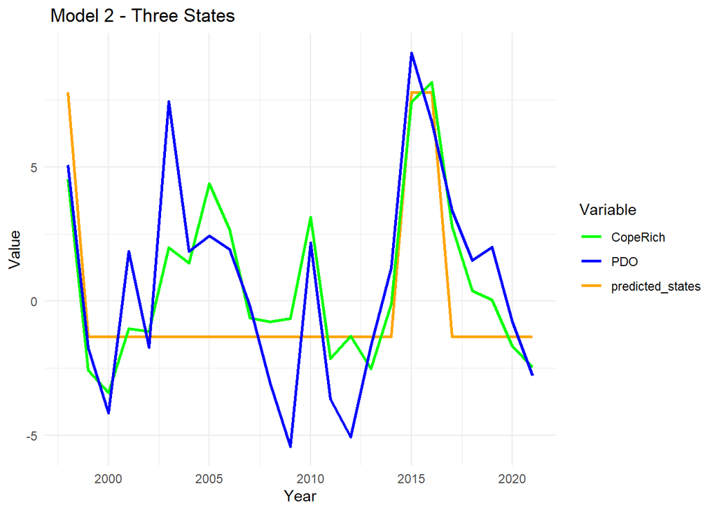

```r
pred <- tibble("Year" = dat$years, "Copepod Richness" = mu[prstates])

#predicted values
pred2 <- pred %>%
  pivot_longer(-Year, names_to = "Copepod Richness", values_to = "Fit")

ggplot() +
   geom_line(data = pred2, aes(x = years, y = Fit, color = "predicted_states"), size = 1) +
  geom_line(data = dat, aes(x = years, y = CopeRich, color = "CopeRich"), size = 1) +
  geom_line(data = dat, aes(x = years, y = PDO_DecMarch, color = "PDO" ), size = 1)+
  scale_color_manual(values = c(PDO = "blue", SST = "red", CopeRich = "green",
                                FishInx = "purple", predicted_states = "orange")) +
  labs(title = " Model 2 - Three States", x = "Year", y = "Value", color = "Variable") +
  theme_minimal()
```

Compared to model 1, model 2 produces a poor visual fit to the data, with a narrower peak later in the timeseries. Because of this we assumed 2 states in the other models we tested.

## Model 3 Copepods and PDO

Because Copepods and PDO have such a clear relationship visually, we started by looking at a model considering both copepod richness and PDO as intercepts, with no covariates informing the transition.

```r
#Copepods and PDO as intercepts
mod3 = depmix(list(CopeRich ~1, PDO~1),
             nstates = 2,
             transition = ~1,
             family = list(gaussian(),gaussian()),
             data=dat)

fitmod3 = fit(mod3)
```

```
## converged at iteration 27 with logLik: -110.5438
```

```r
#Find best fit
iter <-100
seeds<-sample(100:1000, size = iter, replace = F)
best3 <- 1e10
best_model3 <- NA
for(i in 1:iter){
  set.seed(seeds[i])
  fitmod3 <- fit(mod3)
  if(AIC(fitmod3)< best3){
    best_model3 <- fitmod3
    best3 <- AIC(fitmod3)
  }
}
```

[output not shown]

[output cut: 45 more lines]

[output not shown]

```r
summary(best_model3)
```

```
## Initial state probabilities model
## pr1 pr2
##   0   1
##
## Transition matrix
##         toS1  toS2
## fromS1 0.750 0.250
## fromS2 0.386 0.614
##
## Response parameters
## Resp 1 : gaussian
## Resp 2 : gaussian
##     Re1.(Intercept) Re1.sd Re2.(Intercept) Re2.sd
## St1          -1.502  0.989          -1.946  2.262
## St2           3.460  2.482           4.030  2.625
```

This model still preferred state one, with a ~75% probability of staying in one and ~25% chance of transitioning to two. There was a ~61% change of state two to stay in state two and a ~39% chance to transition back to state one. Note there are values for the intercepts and sd for Re1 (coperich) and Re2 (PDO) in this model.

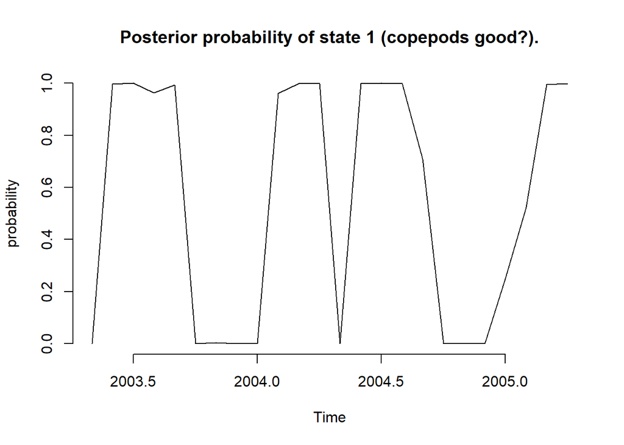

```r
plot(ts(posterior(best_model3, type="smoothing")[,1], start=c(2003,5), deltat=1/12),ylab="probability",
     main="Posterior probability of state 1 (copepods good?).",
     frame=FALSE)
```

```r
prstates<-apply(posterior(best_model3)[,c("S1", "S2")],1, which.max)
mu<-summary(best_model3)[,1]
```

```
## Initial state probabilities model
## pr1 pr2
##   0   1
##
## Transition matrix
##         toS1  toS2
## fromS1 0.750 0.250
## fromS2 0.386 0.614
##
## Response parameters
## Resp 1 : gaussian
## Resp 2 : gaussian
##     Re1.(Intercept) Re1.sd Re2.(Intercept) Re2.sd
## St1          -1.502  0.989          -1.946  2.262
## St2           3.460  2.482           4.030  2.625
```

```r
mu3<-summary(best_model3)[,3]
```

```
## Initial state probabilities model
## pr1 pr2
##   0   1
##
## Transition matrix
##         toS1  toS2
## fromS1 0.750 0.250
## fromS2 0.386 0.614
##
## Response parameters
## Resp 1 : gaussian
## Resp 2 : gaussian
##     Re1.(Intercept) Re1.sd Re2.(Intercept) Re2.sd
## St1          -1.502  0.989          -1.946  2.262
## St2           3.460  2.482           4.030  2.625
```

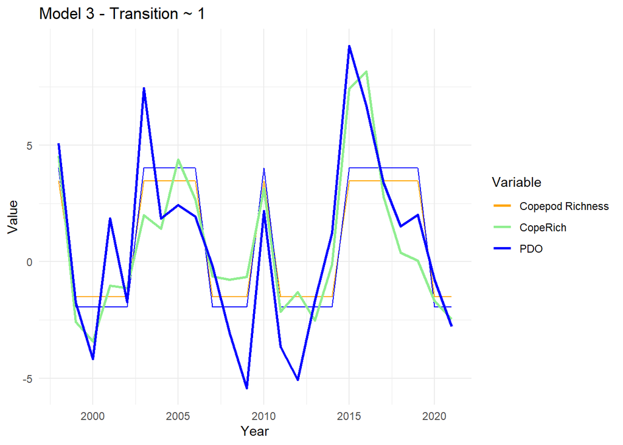

```r
pred <- tibble("Year" = dat$years, "Copepod Richness" = mu[prstates],"PDO" = mu3[prstates])
pred3<-pred %>% pivot_longer(-Year, names_to = "Covariates", values_to = "Fit")


ggplot() +
  geom_line(data = pred3, aes(x = Year, y = Fit, group = Covariates, color = Covariates)) +
  geom_line(data = dat, aes(x = years, y = CopeRich, color = "CopeRich"), linewidth = 1) +
  geom_line(data = dat, aes(x = years, y = PDO_DecMarch, color = "PDO"), linewidth = 1) +
  scale_color_manual(values = c("orange", "lightgreen", "blue")) +  # Assign distinct colors for each line in pred3
  labs(title = "Model 3 - Transition ~ 1", x = "Year", y = "Value", color = "Variable") +
  theme_minimal()
```

## Model 4 Copepods and PDO with transition informed by PDO

Next we wanted to look at copepod richness and PDO with the transition informed by the PDO.

```r
#Copepods and PDO as intercepts where the transition is informed by PDO
mod4 = depmix(list(CopeRich ~1, PDO~1),
              nstates = 2,
              transition = ~PDO,
              family = list(gaussian(),gaussian()),
              data=dat)
fitmod4 = fit(mod4)
```

```
## converged at iteration 15 with logLik: -109.5888
```

```r
#Find best fit
iter <-100
seeds<-sample(100:1000, size = iter, replace = F)
best4 <- 1e10
best_model4 <- NA
for(i in 1:iter){
  set.seed(seeds[i])
  fitmod4 <- fit(mod4)
  if(AIC(fitmod4)< best4){
    best_model4 <- fitmod4
    best4 <- AIC(fitmod4)
  }
}
```

[output not shown]

[output cut: 45 more lines]

[output not shown]

```r
summary(best_model4)
```

```
## Initial state probabilities model
## pr1 pr2
##   0   1
##
## Transition model for state (component) 1
## Model of type multinomial (mlogit), formula: ~PDO
## Coefficients:
##             St1         St2
## (Intercept)   0 -1.29546079
## PDO           0 -0.07655197
## Probalities at zero values of the covariates.
## 0.78507 0.21493
##
## Transition model for state (component) 2
## Model of type multinomial (mlogit), formula: ~PDO
## Coefficients:
##             St1        St2
## (Intercept)   0 -1.1876390
## PDO           0  0.4095372
## Probalities at zero values of the covariates.
## 0.7663185 0.2336815
##
##
## Response parameters
## Resp 1 : gaussian
## Resp 2 : gaussian
##     Re1.(Intercept) Re1.sd Re2.(Intercept) Re2.sd
## St1          -1.438  1.019          -1.803  2.325
## St2           3.649  2.414           4.167  2.628
```

This transition matrix isn’t interpretable as is, but we’ll come back to that later. One question is whether or not this is appropriate, to model PDO as an intercept and use it also as a covariate. Is this confounding? Poor practice?

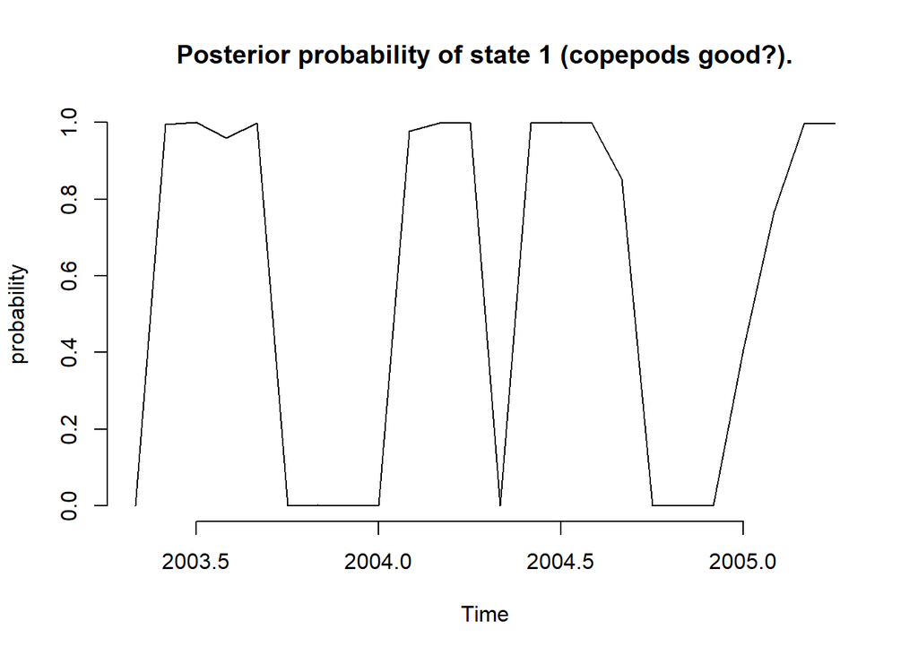

```r
plot(ts(posterior(best_model4, type="smoothing")[,1], start=c(2003,5), deltat=1/12),ylab="probability",
     main="Posterior probability of state 1 (copepods good?).",
     frame=FALSE)
```

```r
prstates<-apply(posterior(best_model4)[,c("S1", "S2")],1, which.max)
mu<-summary(best_model4)[,1]
```

```
## Initial state probabilities model
## pr1 pr2
##   0   1
##
## Transition model for state (component) 1
## Model of type multinomial (mlogit), formula: ~PDO
## Coefficients:
##             St1         St2
## (Intercept)   0 -1.29546079
## PDO           0 -0.07655197
## Probalities at zero values of the covariates.
## 0.78507 0.21493
##
## Transition model for state (component) 2
## Model of type multinomial (mlogit), formula: ~PDO
## Coefficients:
##             St1        St2
## (Intercept)   0 -1.1876390
## PDO           0  0.4095372
## Probalities at zero values of the covariates.
## 0.7663185 0.2336815
##
##
## Response parameters
## Resp 1 : gaussian
## Resp 2 : gaussian
##     Re1.(Intercept) Re1.sd Re2.(Intercept) Re2.sd
## St1          -1.438  1.019          -1.803  2.325
## St2           3.649  2.414           4.167  2.628
```

```r
mu4<-summary(best_model4)[,3]
```

```
## Initial state probabilities model
## pr1 pr2
##   0   1
##
## Transition model for state (component) 1
## Model of type multinomial (mlogit), formula: ~PDO
## Coefficients:
##             St1         St2
## (Intercept)   0 -1.29546079
## PDO           0 -0.07655197
## Probalities at zero values of the covariates.
## 0.78507 0.21493
##
## Transition model for state (component) 2
## Model of type multinomial (mlogit), formula: ~PDO
## Coefficients:
##             St1        St2
## (Intercept)   0 -1.1876390
## PDO           0  0.4095372
## Probalities at zero values of the covariates.
## 0.7663185 0.2336815
##
##
## Response parameters
## Resp 1 : gaussian
## Resp 2 : gaussian
##     Re1.(Intercept) Re1.sd Re2.(Intercept) Re2.sd
## St1          -1.438  1.019          -1.803  2.325
## St2           3.649  2.414           4.167  2.628
```

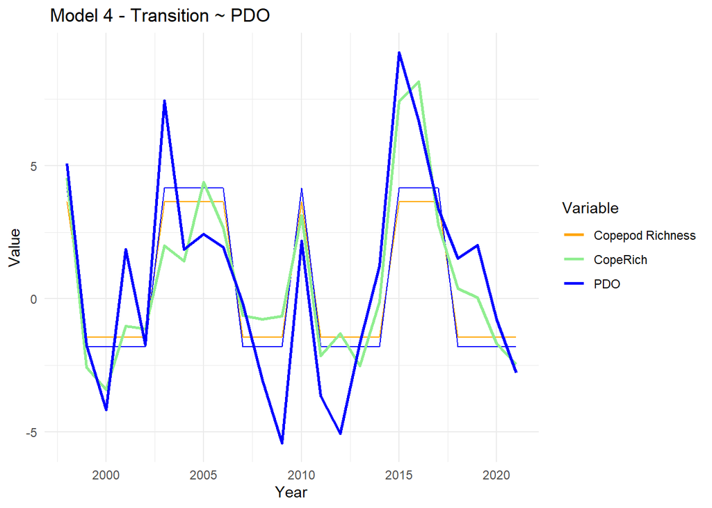

```r
pred <- tibble("Year" = dat$years, "Copepod Richness" = mu[prstates],"PDO" = mu4[prstates])
pred4<-pred %>% pivot_longer(-Year, names_to = "Covariates", values_to = "Fit")

ggplot() +
  geom_line(data = pred4, aes(x = Year, y = Fit, group = Covariates, color = Covariates)) +
  geom_line(data = dat, aes(x = years, y = CopeRich, color = "CopeRich"), linewidth = 1) +
  geom_line(data = dat, aes(x = years, y = PDO_DecMarch, color = "PDO"), linewidth = 1) +
  scale_color_manual(values = c("orange", "lightgreen", "blue")) +  # Assign distinct colors for each line in pred3
  labs(title = " Model 4 - Transition ~ PDO", x = "Year", y = "Value", color = "Variable") +
  theme_minimal()
```

Models 3 and 4 produce similar fits to the data, the only obvious difference is that model 4 spends less time in the higher state than model 3.

## Model 5 Copepods informed by PDO

In this model, we wanted to relate copepod richness to PDO directly, with no transtion.

```r
#Copepods as they relate to PDO
mod5 = depmix(list(CopeRich ~PDO),
              nstates = 2,
              transition = ~1,
              family = list(gaussian()),
              data=dat)
fitmod5 = fit(mod5)
```

```
## converged at iteration 41 with logLik: -41.20702
```

```r
#Find best fit
iter <-100
seeds<-sample(100:1000, size = iter, replace = F)
best5 <- 1e10
best_model5 <- NA
for(i in 1:iter){
  set.seed(seeds[i])
  fitmod5 <- fit(mod5)
  if(AIC(fitmod5)< best5){
    best_model5 <- fitmod5
    best5 <- AIC(fitmod5)
  }
}
```

[output not shown]

[output cut: 45 more lines]

[output not shown]

```r
summary(best_model5)
```

```
## Initial state probabilities model
## pr1 pr2
##   0   1
##
## Transition matrix
##         toS1  toS2
## fromS1 0.730 0.270
## fromS2 0.269 0.731
##
## Response parameters
## Resp 1 : gaussian
##     Re1.(Intercept) Re1.PDO Re1.sd
## St1          -1.184   0.463  0.534
## St2           1.344   0.684  1.219
```

This model has an interpreatable transition matrix, where the probability of staying or leaving each respective state is about ~70-30. Note that we now have PDO as informing our copepod richness in the response parameters.

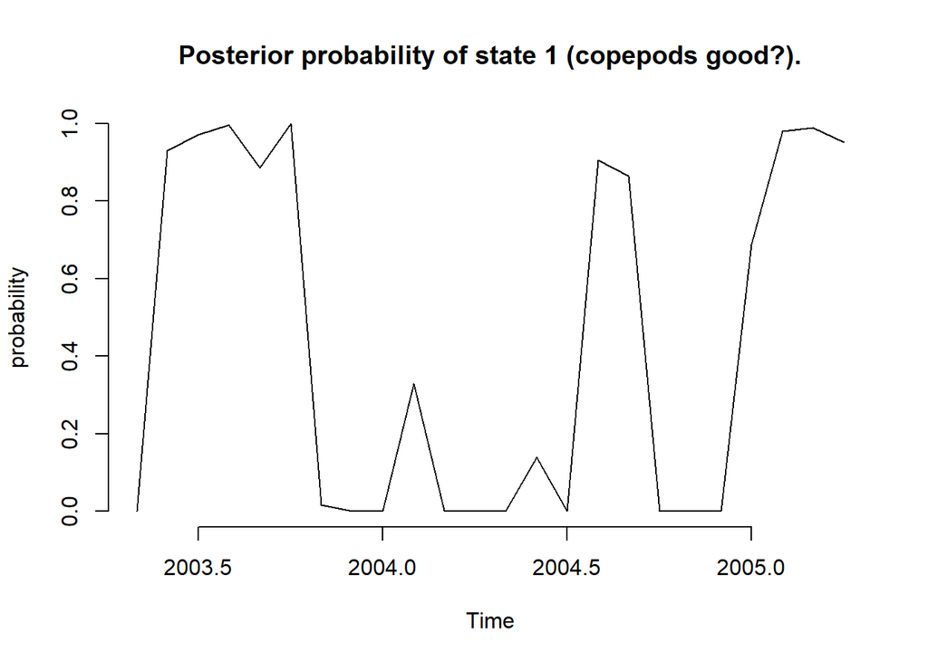

```r
plot(ts(posterior(best_model5, type="smoothing")[,1], start=c(2003,5), deltat=1/12),ylab="probability",
     main="Posterior probability of state 1 (copepods good?).",
     frame=FALSE)
```

```r
prstates<-apply(posterior(best_model5)[,c("S1", "S2")],1, which.max)
mu<-summary(best_model5)[,1]
```

```
## Initial state probabilities model
## pr1 pr2
##   0   1
##
## Transition matrix
##         toS1  toS2
## fromS1 0.730 0.270
## fromS2 0.269 0.731
##
## Response parameters
## Resp 1 : gaussian
##     Re1.(Intercept) Re1.PDO Re1.sd
## St1          -1.184   0.463  0.534
## St2           1.344   0.684  1.219
```

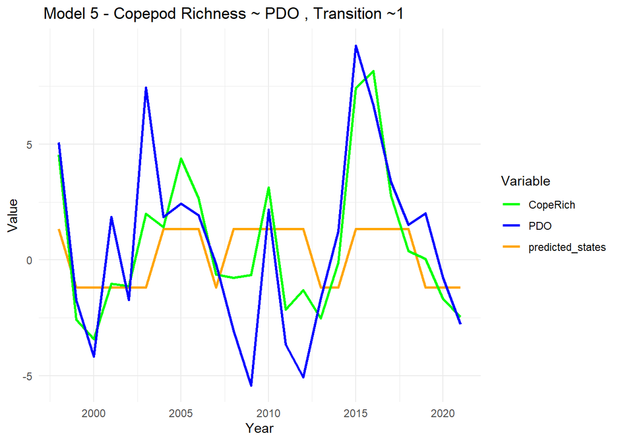

```r
pred <- tibble("Year" = dat$years, "Copepod Richness" = mu[prstates])
pred5<-pred %>% pivot_longer(-Year, names_to = "Copepod Richness", values_to = "Fit")

ggplot() +
   geom_line(data = pred5, aes(x = years, y = Fit, color = "predicted_states"), size = 1) +
  geom_line(data = dat, aes(x = years, y = CopeRich, color = "CopeRich"), size = 1) +
  geom_line(data = dat, aes(x = years, y = PDO_DecMarch, color = "PDO" ), size = 1)+
  scale_color_manual(values = c(PDO = "blue", SST = "red", CopeRich = "green",
                                FishInx = "purple", predicted_states = "orange")) +
  labs(title = " Model 5 - Copepod Richness ~ PDO , Transition ~1", x = "Year", y = "Value", color = "Variable") +
  theme_minimal()
```

Copepod richness and PDO data have the closest correlation, and it seemed reasonable to relate them to each other and model the variation of Copepod Richness as a function of PDO. Admittedly, we are not sure if this is a appropriate entry to the `depmix()` function but the results for models 5 and 6 were interesting so we included them.

## Model 6 Copepods informed by PDO with PDO informing transition

This model is the same as model 5, but using PDO as a covariate for transition, which could be inappropriate for hmm model specification. But, we wanted to explore it.

For the intercept we chose to model Copepod Richness ~ PDO. These data sets have the closest correlation and so this was done to test of the fit could be improved by modeling the variation of Copepod Richness as a function of PDO. Admittedly, we are not sure if this is a appropriate entry to the `depmix()` function but the results for models 5 and 6 were interesting so we included them.

# Model 6

```r
#Copepods as they relate to PDO where the transition is informed by PDO
mod6 = depmix(list(CopeRich ~PDO),
              nstates = 2,
              transition = ~PDO,
              family = list(gaussian()),
              data=dat)
fitmod6 = fit(mod6)
```

```
## converged at iteration 87 with logLik: -41.46761
```

```r
#Find best fit
iter <-100
seeds<-sample(100:1000, size = iter, replace = F)
best6 <- 1e10
best_model6 <- NA
for(i in 1:iter){
  set.seed(seeds[i])
  fitmod6 <- fit(mod6)
  if(AIC(fitmod6)< best6){
    best_model6 <- fitmod6
    best6 <- AIC(fitmod6)
  }
}
```

[output not shown]

[output cut: 45 more lines]

[output not shown]

```r
summary(best_model6)
```

```
## Initial state probabilities model
## pr1 pr2
##   1   0
##
## Transition model for state (component) 1
## Model of type multinomial (mlogit), formula: ~PDO
## Coefficients:
##             St1       St2
## (Intercept)   0 -6.846649
## PDO           0 -4.202727
## Probalities at zero values of the covariates.
## 0.9989381 0.001061883
##
## Transition model for state (component) 2
## Model of type multinomial (mlogit), formula: ~PDO
## Coefficients:
##             St1         St2
## (Intercept)   0 -12.4472966
## PDO           0   0.1336125
## Probalities at zero values of the covariates.
## 0.9999961 3.928313e-06
##
##
## Response parameters
## Resp 1 : gaussian
##     Re1.(Intercept) Re1.PDO Re1.sd
## St1           0.136   0.892  1.151
## St2          -0.220   0.199  0.704
```

Again, given that we included PDO as a transition covariate, the matrix was not interpretable as is in the model summary, but we address this in the More Model Diagnostics Section.

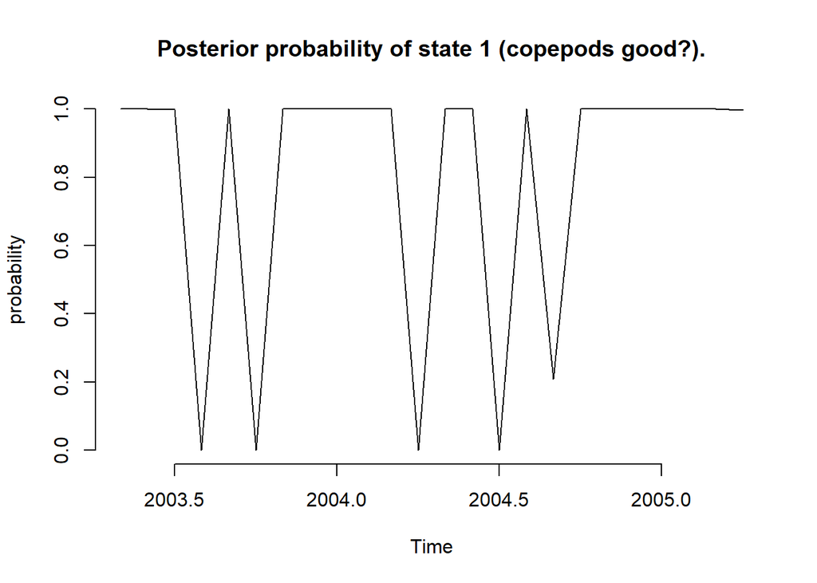

```r
plot(ts(posterior(best_model6, type="smoothing")[,1], start=c(2003,5), deltat=1/12),ylab="probability",
     main="Posterior probability of state 1 (copepods good?).",
     frame=FALSE)
```

```r
prstates<-apply(posterior(best_model6)[,c("S1", "S2")],1, which.max)
mu<-summary(best_model6)[,1]
```

```
## Initial state probabilities model
## pr1 pr2
##   1   0
##
## Transition model for state (component) 1
## Model of type multinomial (mlogit), formula: ~PDO
## Coefficients:
##             St1       St2
## (Intercept)   0 -6.846649
## PDO           0 -4.202727
## Probalities at zero values of the covariates.
## 0.9989381 0.001061883
##
## Transition model for state (component) 2
## Model of type multinomial (mlogit), formula: ~PDO
## Coefficients:
##             St1         St2
## (Intercept)   0 -12.4472966
## PDO           0   0.1336125
## Probalities at zero values of the covariates.
## 0.9999961 3.928313e-06
##
##
## Response parameters
## Resp 1 : gaussian
##     Re1.(Intercept) Re1.PDO Re1.sd
## St1           0.136   0.892  1.151
## St2          -0.220   0.199  0.704
```

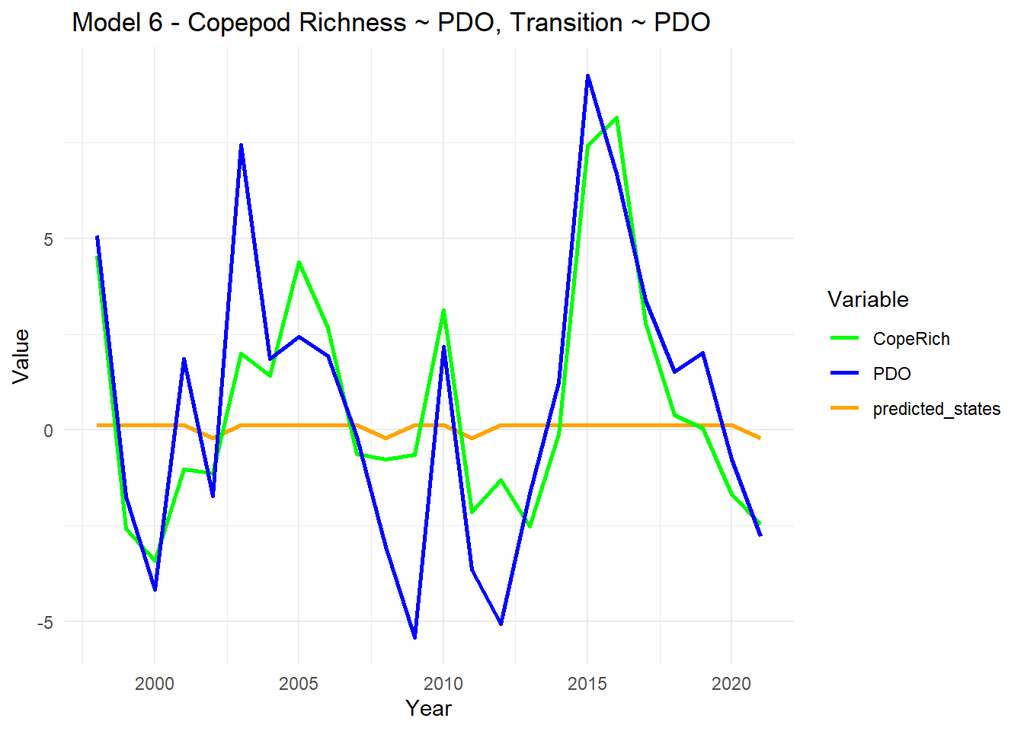

```r
pred <- tibble("Year" = dat$years, "Copepod Richness" = mu[prstates])
pred6<-pred %>% pivot_longer(-Year, names_to = "Copepod Richness", values_to = "Fit")

ggplot() +
   geom_line(data = pred6, aes(x = years, y = Fit, color = "predicted_states"), size = 1) +
  geom_line(data = dat, aes(x = years, y = CopeRich, color = "CopeRich"), size = 1) +
  geom_line(data = dat, aes(x = years, y = PDO_DecMarch, color = "PDO" ), size = 1)+
  scale_color_manual(values = c(PDO = "blue", SST = "red", CopeRich = "green",
                                FishInx = "purple", predicted_states = "orange")) +
  labs(title = " Model 6 - Copepod Richness ~ PDO, Transition ~ PDO", x = "Year", y = "Value", color = "Variable") +
  theme_minimal()
```

Visually, model 6 produced the worst fit to the data. This model suggests there is a dominant state near the mean of the data and the second state is only marginally different. The dampening of the oscillation must be from the transition being informed directly by PDO.

#Model Selection with AIC

```r
mods <- c("1","2","3","4","5","6")
aic <- c(AIC(best_model1), AIC(best_model2), AIC(best_model3), AIC(best_model4), AIC(best_model5),AIC(best_model6))
delta.aic <- aic-min(aic)
tab <- cbind.data.frame(mods, aic, delta.aic)

tab
```

```
##   mods       aic  delta.aic
## 1    1 123.36068  27.962542
## 2    2 125.21442  29.816289
## 3    3 243.08766 147.689530
## 4    4 245.17760 149.779465
## 5    5  97.76613   2.367998
## 6    6  95.39813   0.000000
```

AIC tells us that the best model would be model 6, although it is just marginally better than model 5 with a delta AIC of just over 2. The delta AIC values are only about 2 different between models 1-2 and 3-4 and 5-6 respectively. Each set of models are the most similar to each other within the models tested and these AIC values indicate little to no support for one approach within each group to be significantly better than the other. AIC values do indicate significantly better performance between these sets of models, however this support is not supported by looking at visual fits of the data. The two best models, 5 and 6, produce the worst visual fits to the data of any models tested. It is unclear why AIC is selecting these models as the best, but it does seem that AIC favors the simple models with only one intercept rather than models with two intercepts. Because of the apparent poor fit of models 5 and 6, it seems other methods of model selection such as Cross Validation or leave One Out may be more appropriate here than AIC.

# More Model Diagnostics

The following function allows us to interpret the transition matrix when there is a covariate informing the transition.

```r
#create a funciton to help build transition matrices
convert_probs <- function(fit, coef_value = 0) {
  # extract coefficients
  p1 <- fit@transition[[1]]@parameters$coefficients
  p2 <- fit@transition[[2]]@parameters$coefficients

  # assemble transition matrix in mlogit space
  m <- matrix(0, 2, 2)
  m[1,] <- p1[1,] + p1[2,] * coef_value #intercept + slope * coefficient
  m[2,] <- p2[1,] + p2[2,] * coef_value

  # exponentiate
  m <- exp(m)

  # normalize
  m[1,] <- m[1,] / sum(m[1,])
  m[2,] <- m[2,] / sum(m[2,])
  return(m)
}
```

Let’s look at all the model together. Note that the above function was applied to models 4 and 6, which did not have an interpretable transition matrix.

```r
#Look at the transition matrices and variance
summary(fitmod1)
```

```
## Initial state probabilities model
## pr1 pr2
##   1   0
##
## Transition matrix
##         toS1  toS2
## fromS1 0.598 0.402
## fromS2 0.246 0.754
##
## Response parameters
## Resp 1 : gaussian
##     Re1.(Intercept) Re1.sd
## St1           3.504  2.552
## St2          -1.414  1.050
```

```r
summary(fitmod2)
```

```
## Initial state probabilities model
## pr1 pr2 pr3
##   0   0   1
##
## Transition matrix
##         toS1  toS2  toS3
## fromS1 0.781 0.144 0.075
## fromS2 0.488 0.512 0.000
## fromS3 0.342 0.322 0.336
##
## Response parameters
## Resp 1 : gaussian
##     Re1.(Intercept) Re1.sd
## St1          -1.344  1.067
## St2           2.649  1.020
## St3           6.627  1.631
```

```r
summary(fitmod3)
```

```
## Initial state probabilities model
## pr1 pr2
##   0   1
##
## Transition matrix
##         toS1  toS2
## fromS1 0.750 0.250
## fromS2 0.386 0.614
##
## Response parameters
## Resp 1 : gaussian
## Resp 2 : gaussian
##     Re1.(Intercept) Re1.sd Re2.(Intercept) Re2.sd
## St1          -1.502  0.989          -1.946  2.262
## St2           3.460  2.482           4.030  2.625
```

```r
summary(fitmod4) # no transition matrix
```

```
## Initial state probabilities model
## pr1 pr2
##   1   0
##
## Transition model for state (component) 1
## Model of type multinomial (mlogit), formula: ~PDO
## Coefficients:
##             St1        St2
## (Intercept)   0  1.1895326
## PDO           0 -0.4097828
## Probalities at zero values of the covariates.
## 0.2333425 0.7666575
##
## Transition model for state (component) 2
## Model of type multinomial (mlogit), formula: ~PDO
## Coefficients:
##             St1        St2
## (Intercept)   0 1.29568109
## PDO           0 0.07641147
## Probalities at zero values of the covariates.
## 0.2148928 0.7851072
##
##
## Response parameters
## Resp 1 : gaussian
## Resp 2 : gaussian
##     Re1.(Intercept) Re1.sd Re2.(Intercept) Re2.sd
## St1           3.650  2.414           4.168  2.628
## St2          -1.438  1.019          -1.803  2.325
```

```r
summary(fitmod5)
```

```
## Initial state probabilities model
## pr1 pr2
##   0   1
##
## Transition matrix
##         toS1  toS2
## fromS1 0.453 0.547
## fromS2 0.361 0.639
##
## Response parameters
## Resp 1 : gaussian
##     Re1.(Intercept) Re1.PDO Re1.sd
## St1          -0.372   0.228  0.711
## St2           0.108   0.936  1.115
```

```r
summary(fitmod6) # no transition matrix
```

```
## Initial state probabilities model
## pr1 pr2
##   1   0
##
## Transition model for state (component) 1
## Model of type multinomial (mlogit), formula: ~PDO
## Coefficients:
##             St1       St2
## (Intercept)   0 -6.846651
## PDO           0 -4.202754
## Probalities at zero values of the covariates.
## 0.9989381 0.001061881
##
## Transition model for state (component) 2
## Model of type multinomial (mlogit), formula: ~PDO
## Coefficients:
##             St1          St2
## (Intercept)   0 -10.29414423
## PDO           0   0.02978694
## Probalities at zero values of the covariates.
## 0.9999662 3.382948e-05
##
##
## Response parameters
## Resp 1 : gaussian
##     Re1.(Intercept) Re1.PDO Re1.sd
## St1           0.136   0.892  1.151
## St2          -0.220   0.199  0.704
```

```r
#get the transition matrices
convert_probs(fitmod4)
```

```
##           [,1]      [,2]
## [1,] 0.2333425 0.7666575
## [2,] 0.2148928 0.7851072
```

```r
convert_probs(fitmod6)
```

```
##           [,1]         [,2]
## [1,] 0.9989381 1.061881e-03
## [2,] 0.9999662 3.382948e-05
```

The state 1 transition probabilities in models 3 and 4 showed an opposite pattern, yet produced very similar fits to the data. The difference appeared to only be shown in the most recent years, where in model 4 there was a more rapid shift out of the higher state. This aligns with what we would expect with the change in transition probabilities from state 1 to state 2.

Model 5 appeared to have smaller intercept values which makes sense as the predicted states were closer to 0 than in the other models.

# Results

Summarize the model you’ve created. Specifically,

- Does it converge?

- How many states seem to be most supported?

Compared to model 1, model two with 3 states produced a poor visual fit to the data. Because of this we assumed 2 states in the other models we tested. This aligned with our visual estimates of two states.

- Plot the time series of estimated states. What does this mean?

The plots of estimated states show the underlying pattern that may exist if there is in fact a shift between states. The variation in the data from this pattern would be related to unexplained error related to covariates other than the underlying states. Visually there appears to be good support for two underlying states, however the estimated states in our top AICc ranked model do not appear to fit the data well, indicating that AICc may not be the best metric to use here. It definitely highlights the dangers of blindly trusting AIC without further model checks.

# Discussion

## What we’re still confused about

One question we had is that our ‘best’ model based on AIC values did not appear to be a good fit to the data visually. When this is the case, what should our next steps be? Visually confirming model fit seems to overrule AIC values when those diagnostics are contradictory, is this true?

We didn’t have a good handle on how the ‘nstates’ and ‘transitions’ inputs to the models interacted and what type of model diagnostics would help us quantify underlying relationships. After we were in pretty deep we realized having PDO in both the model list (related to copepod richness or as an independent intercept) and as a covarate for transition may be innappropriate, but are unsure and would like more information.

PDO has a very strong correlative pattern with copepod richness. We ran several combinations of model to examine the strength of this relationship. We produced some models with decent looking fits, but these models were not as highly ranked by AIC as other, seemingly less well fitting models. Is AIC a poor choice? We have a suspicion this question will be answered in the next lecture(s)…

# Team contributions

Madison took point on coding, Nick helped with coding and compiled it into the final rmd, and Nick and Karl did writing and Madison proofread and organized the .Rmd document.